# Data Viz for Case Study

Hasan

2023-09-30

# Design marketing strategies aimed at converting casual riders into annual members

## Phase-I

Explore the data and look for relation pattern

#### Import the Clean data

Cleaning process has been done now make data viz using R

```r
library(tidyverse)
library(scales)
data_df <- read.csv('data_clean.csv')
```

data type `day_of_week` into character which will help in the chart axis  
‘1’ cross ponds to ‘Mon’ Also replace `Customer` with `walk-in` and `Subscriber` with `Member` for clarity purpose

```r
data_df$day_of_week = as.character(data_df$day_of_week)
data_df$usertype = gsub("Customer","walk-in",data_df$usertype)
data_df$usertype = gsub("Subscriber","Member",data_df$usertype)
```

#### Customer proportion

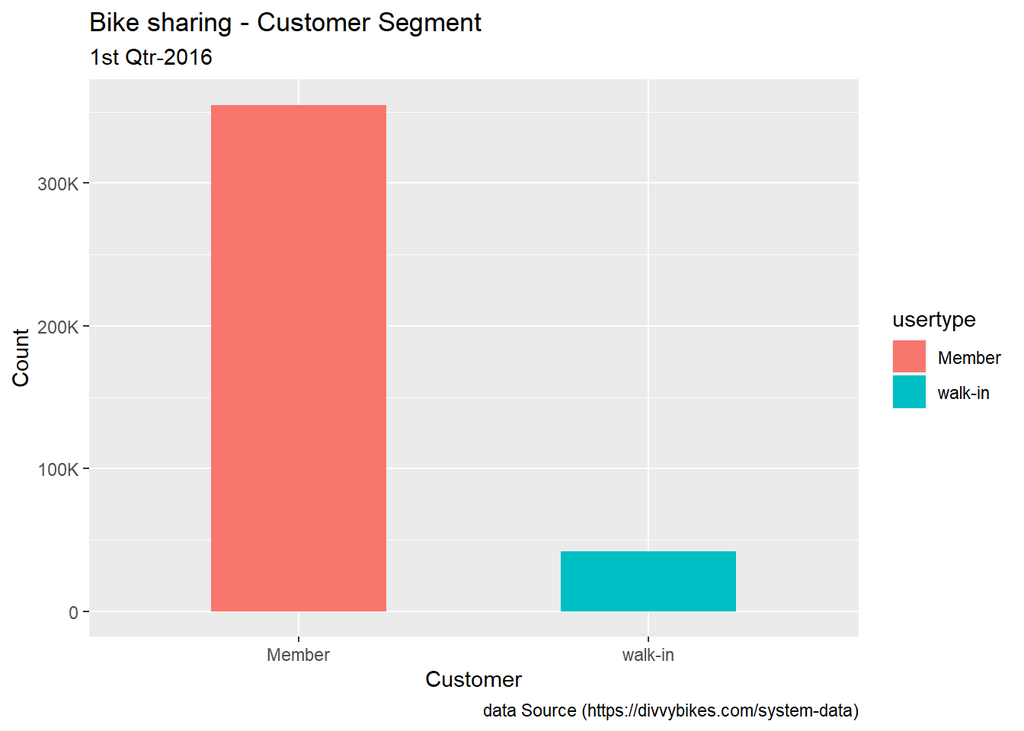

```r
customer_count <- data_df %>%
  select(usertype) %>% count(usertype)

ggplot(data = customer_count,mapping = aes(x=usertype,y=n))+
  geom_col(mapping = aes(fill=usertype),width = 0.5)+
  scale_y_continuous(labels = label_number(scale_cut = cut_short_scale()))+
  labs(title = "Bike sharing - Customer Segment",
       subtitle = "1st Qtr-2016",
       caption = "data Source (https://divvybikes.com/system-data)",
       y = "Count",
       x = "Customer"
  )
```

Members are the largest source of the income for the company

#### Rides for Weekdays

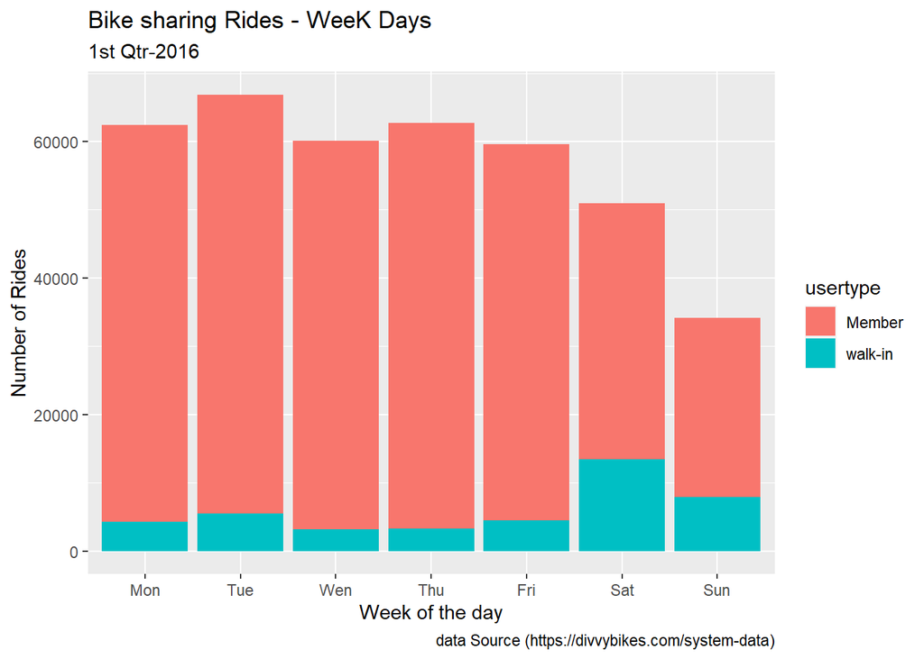

```r
trip_wk_day <- data_df %>%
  group_by(usertype,day_of_week)

ggplot(data = trip_wk_day)+
  geom_bar(mapping = aes(x=day_of_week,fill=usertype))+
  labs(title = "Bike sharing Rides - WeeK Days",
       subtitle = "1st Qtr-2016",
       caption = "data Source (https://divvybikes.com/system-data)",
       y = "Number of Rides",
       )+
  scale_x_discrete(
    "Week of the day",
    labels= c(
      "1" = "Mon",
      "2" = "Tue",
      "3" = "Wen",
      "4" = "Thu",
      "5" = "Fri",
      "6" = "Sat",
      "7" = "Sun"
    )
  )
```

Tuesday is busiest day for the company with number of rides approx. 70K  
Sunday is not so busy in over all. Note here `walk-in` customer taking more rides in Saturday

#### Rides Average Duration

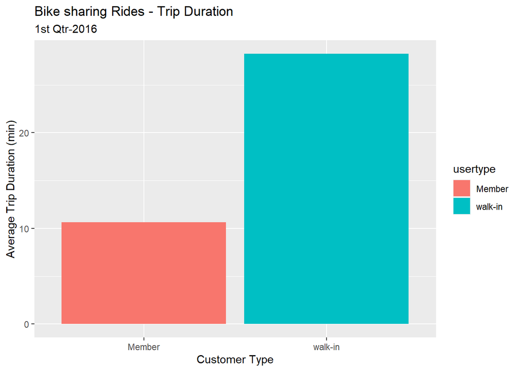

```r
avg_trip_user <- data_df %>%
  group_by(usertype) %>%
  summarise(avg_trip_duration=mean(tripduration)/60)

ggplot(data = avg_trip_user,aes(x=usertype,y=avg_trip_duration))+
  geom_col(mapping = aes(fill=usertype))+
  labs(title = "Bike sharing Rides - Trip Duration",
       subtitle = "1st Qtr-2016",
       y = "Average Trip Duration (min)",
       x= "Customer Type"
  )
```

Average duration per ride for `Members` is 10.65 min and for `walk-in` 28.24 min

#### Rides Average duration durine Week

```r
avg_trip_user_day <- data_df %>%
  group_by(usertype,day_of_week) %>%
  summarise(avg_trip_duration=mean(tripduration)/60)
```

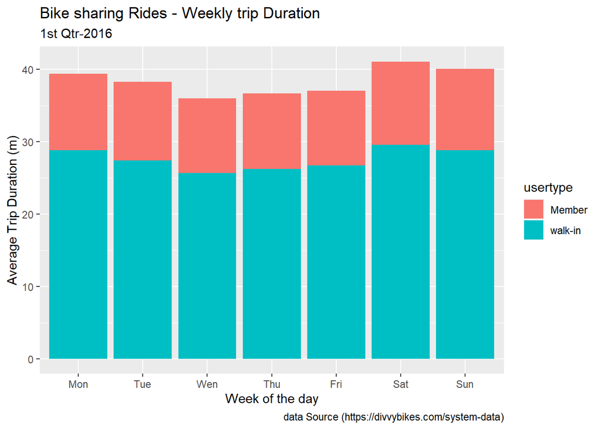

```r
ggplot(data = avg_trip_user_day,aes(x=day_of_week,y=avg_trip_duration))+
  geom_col(aes(fill=usertype))+

  labs(title = "Bike sharing Rides - Weekly trip Duration",
       subtitle = "1st Qtr-2016",
       caption = "data Source (https://divvybikes.com/system-data)",
       y = "Average Trip Duration (m)",
  )+
  scale_x_discrete(
    "Week of the day",
    labels= c(
      "1" = "Mon",
      "2" = "Tue",
      "3" = "Wen",
      "4" = "Thu",
      "5" = "Fri",
      "6" = "Sat",
      "7" = "Sun"
    )
  )
```

`walk-in` customer tends to ride for longer period compare to `Member`

## Phase-I - conlusion:

`walk-in` customer takes longer trips compare to `Members` but `Member` customers are largest portion so will focus on `Member` and investigate which segment of the `walk-in` can be converted into`Member` which is the main purpose of this analysis task

## Phase-II

We are interested in the Members data only but data has few null in the gender

```r
unique(data_df$gender)
```

```
## [1] "Male"   "Female" ""
```

#### Member Ride with over time period

```r
gender_clean <- data_df %>% filter(usertype =="Member" & gender!="")
gender_clean$date_new = date(ymd_hms(gender_clean$starttime))

gender_clean <- gender_clean %>%
  group_by(date_new,gender) %>%
  summarise(average_trip=mean(tripduration)/60)
```

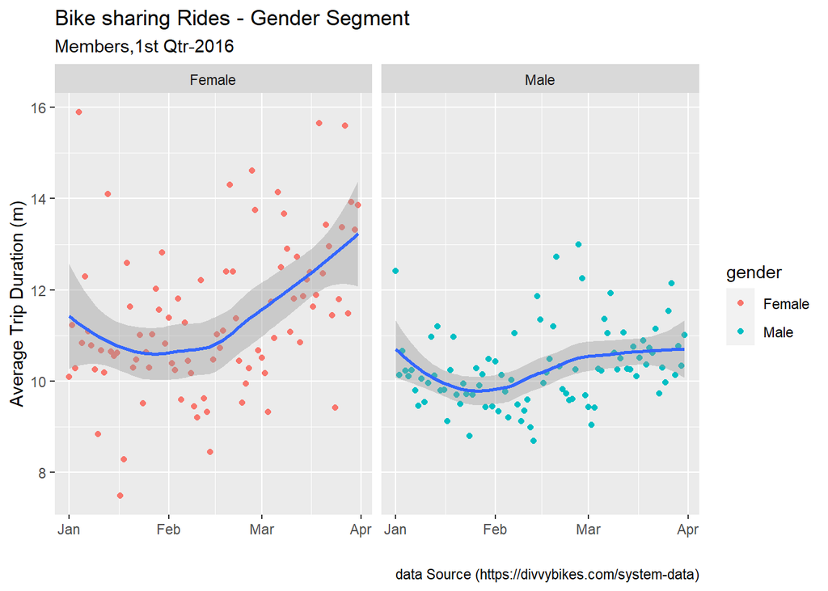

```r
ggplot(data = gender_clean,mapping = aes(x=date_new,y=average_trip))+
  geom_point(aes(color=gender))+
  facet_wrap(~gender)+
  geom_smooth()+
  labs(title = "Bike sharing Rides - Gender Segment",
       subtitle = "Members,1st Qtr-2016",
       caption = "data Source (https://divvybikes.com/system-data)",
       y = "Average Trip Duration (m)",
       x= ""
  )
```

Female taking rides shows positive trends over the time as compare male. Female riding demands between March and April Male trends stays linear, female also renting for longer period than male.

#### Member Ride w.r.t Age

##### Constrain-1 :

few abnormalities for birth year as it goes up-to 1900 (more 100 year old) rider. Forth sake clarity analysis restricted to age 70 and below you can adjust accordingly.

*Note:* Analysis is being done for year 2016, age is calculated till year 2016

```r
last_date <- ymd("2016-12-31")
age_clean <- data_df %>% filter(usertype =="Member" & gender!="")
age_clean$date_new <- date(ymd_hms(age_clean$starttime))
age_clean$age <- abs(year(last_date) - age_clean$birthyear)

age_clean <- age_clean %>% filter(age<=70)

age_clean <- age_clean %>%
  group_by(age,gender) %>%
  summarise(average_trip=mean(tripduration)/60)
```

[output not shown]

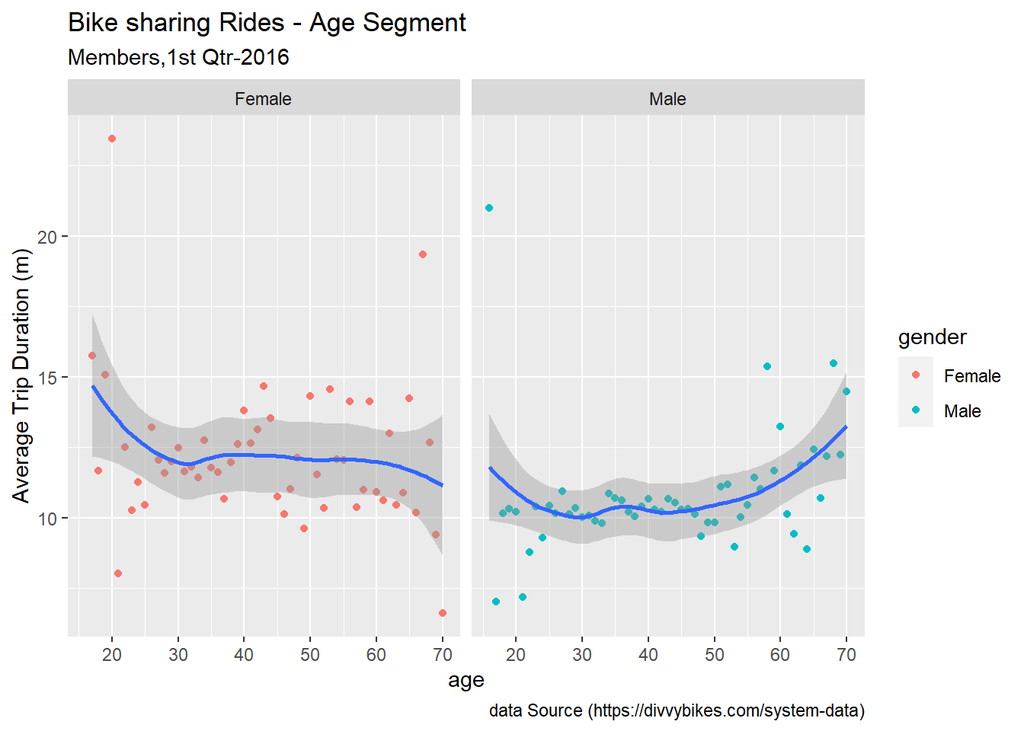

```r
ggplot(data = age_clean,mapping = aes(x=age,y=average_trip))+
  geom_point(aes(color=gender))+
  facet_wrap(~gender)+

  geom_smooth()+
  labs(title = "Bike sharing Rides - Age Segment",
       subtitle = "Members,1st Qtr-2016",
       caption = "data Source (https://divvybikes.com/system-data)",
       y = "Average Trip Duration (m)",
       x= "age"
  )
```